# Clustering based on survey data of a running footwear & apparel company

## Objective

To group the customers of a running footwear & apparel company based on the inputs collected through a survey

## Team Members

- Collaborated with 'Kranthi Kumar kotrika' for Similarity Metrics calculation.

## Data Dictionary

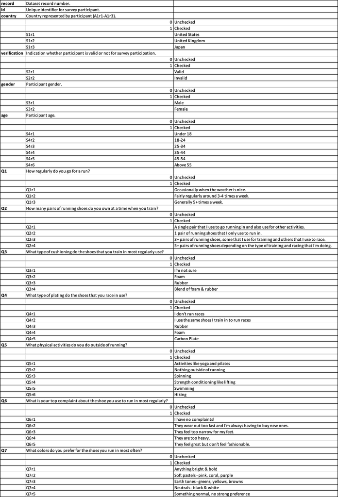

## Importing libraries

```python
# !pip install pandas openpyxl
```

```python
#Import all the necessary packages

import pandas as pd
import numpy as np

import matplotlib.pylab as plt
import seaborn as sns

#to scale the data using z-score
from sklearn.preprocessing import StandardScaler

#importing clustering algorithms
from sklearn.cluster import KMeans
from sklearn.mixture import GaussianMixture

#Silhouette score
from sklearn.metrics import silhouette_score

import warnings
warnings.filterwarnings("ignore")

from google.colab import drive
```

#### Loading the data

```python
drive.mount("/content/drive/", force_remount = True)

path = '/content/drive/My Drive/Northeastern/Course files/IE 7275 - Data Mining/'
data = pd.read_excel(path+'survey_data.xlsx', sheet_name='Dataset')

data.head()
```

|  | record | id | S1r1 | S1r2 | S1r3 | S2r1 | S2r2 | S3r1 | S3r2 | S4r1 | ... | Q6r1 | Q6r2 | Q6r3 | Q6r4 | Q6r5 | Q7r1 | Q7r2 | Q7r3 | Q7r4 | Q7r5 |
| --- | --- | --- | --- | --- | --- | --- | --- | --- | --- | --- | --- | --- | --- | --- | --- | --- | --- | --- | --- | --- | --- |
| 0 | 1 | 9731743 | 1 | 0 | 0 | 1 | 0 | 1 | 0 | 0 | ... | 0 | 1 | 0 | 1 | 0 | 0 | 0 | 1 | 1 | 0 |
| 1 | 2 | 5917428 | 0 | 0 | 1 | 1 | 0 | 1 | 0 | 0 | ... | 0 | 1 | 0 | 0 | 0 | 0 | 0 | 1 | 0 | 0 |
| 2 | 3 | 2459391 | 0 | 0 | 1 | 1 | 0 | 0 | 1 | 0 | ... | 0 | 0 | 0 | 0 | 1 | 0 | 1 | 1 | 0 | 0 |
| 3 | 4 | 3277896 | 0 | 0 | 1 | 1 | 0 | 0 | 1 | 0 | ... | 0 | 0 | 0 | 0 | 1 | 0 | 1 | 0 | 0 | 0 |
| 4 | 5 | 4986375 | 1 | 0 | 0 | 1 | 0 | 0 | 1 | 1 | ... | 0 | 0 | 0 | 0 | 1 | 1 | 0 | 0 | 0 | 0 |

5 rows × 47 columns

#### Check the info of data

```python
data.info()
```

```
<class 'pandas.core.frame.DataFrame'>
RangeIndex: 175 entries, 0 to 174
Data columns (total 47 columns):
 #   Column  Non-Null Count  Dtype
---  ------  --------------  -----
 0   record  175 non-null    int64
 1   id      175 non-null    int64
 2   S1r1    175 non-null    int64
 3   S1r2    175 non-null    int64
 4   S1r3    175 non-null    int64
 5   S2r1    175 non-null    int64
 6   S2r2    175 non-null    int64
 7   S3r1    175 non-null    int64
 8   S3r2    175 non-null    int64
 9   S4r1    175 non-null    int64
```

[output cut: 39 more lines]

**Observations:**

- There are 175 observations and 47 columns in the data.
- All columns have 175 non-null values i.e. there are no missing values.
- All the columns are numerical.

#### Check for duplicates

```python
data[data.duplicated()]
```

|  | record | id | S1r1 | S1r2 | S1r3 | S2r1 | S2r2 | S3r1 | S3r2 | S4r1 | ... | Q6r1 | Q6r2 | Q6r3 | Q6r4 | Q6r5 | Q7r1 | Q7r2 | Q7r3 | Q7r4 | Q7r5 |
| --- | --- | --- | --- | --- | --- | --- | --- | --- | --- | --- | --- | --- | --- | --- | --- | --- | --- | --- | --- | --- | --- |

0 rows × 47 columns

- There are no duplicate records in the data

## Exploratory Data Analysis

#### Summary Statistics

```python
data.describe().T.applymap(lambda x: '{:.2f}'.format(x))
```

|  | count | mean | std | min | 25% | 50% | 75% | max |
| --- | --- | --- | --- | --- | --- | --- | --- | --- |
| record | 175.00 | 88.00 | 50.66 | 1.00 | 44.50 | 88.00 | 131.50 | 175.00 |
| id | 175.00 | 5267811.73 | 2664352.03 | 1035396.00 | 2882270.00 | 5139211.00 | 7396717.00 | 9973724.00 |
| S1r1 | 175.00 | 0.59 | 0.49 | 0.00 | 0.00 | 1.00 | 1.00 | 1.00 |
| S1r2 | 175.00 | 0.18 | 0.38 | 0.00 | 0.00 | 0.00 | 0.00 | 1.00 |
| S1r3 | 175.00 | 0.16 | 0.37 | 0.00 | 0.00 | 0.00 | 0.00 | 1.00 |
| S2r1 | 175.00 | 0.86 | 0.34 | 0.00 | 1.00 | 1.00 | 1.00 | 1.00 |
| S2r2 | 175.00 | 0.15 | 0.36 | 0.00 | 0.00 | 0.00 | 0.00 | 1.00 |
| S3r1 | 175.00 | 0.42 | 0.50 | 0.00 | 0.00 | 0.00 | 1.00 | 1.00 |
| S3r2 | 175.00 | 0.45 | 0.50 | 0.00 | 0.00 | 0.00 | 1.00 | 1.00 |
| S4r1 | 175.00 | 0.21 | 0.41 | 0.00 | 0.00 | 0.00 | 0.00 | 1.00 |
| S4r2 | 175.00 | 0.14 | 0.35 | 0.00 | 0.00 | 0.00 | 0.00 | 1.00 |
| S4r3 | 175.00 | 0.22 | 0.42 | 0.00 | 0.00 | 0.00 | 0.00 | 1.00 |
| S4r4 | 175.00 | 0.22 | 0.42 | 0.00 | 0.00 | 0.00 | 0.00 | 1.00 |
| S4r5 | 175.00 | 0.09 | 0.29 | 0.00 | 0.00 | 0.00 | 0.00 | 1.00 |
| S4r6 | 175.00 | 0.05 | 0.21 | 0.00 | 0.00 | 0.00 | 0.00 | 1.00 |
| Q1r1 | 175.00 | 0.29 | 0.46 | 0.00 | 0.00 | 0.00 | 1.00 | 1.00 |
| Q1r2 | 175.00 | 0.31 | 0.47 | 0.00 | 0.00 | 0.00 | 1.00 | 1.00 |
| Q1r3 | 175.00 | 0.28 | 0.45 | 0.00 | 0.00 | 0.00 | 1.00 | 1.00 |
| Q2r1 | 175.00 | 0.24 | 0.43 | 0.00 | 0.00 | 0.00 | 0.00 | 1.00 |
| Q2r2 | 175.00 | 0.30 | 0.46 | 0.00 | 0.00 | 0.00 | 1.00 | 1.00 |
| Q2r3 | 175.00 | 0.27 | 0.44 | 0.00 | 0.00 | 0.00 | 1.00 | 1.00 |
| Q2r4 | 175.00 | 0.09 | 0.29 | 0.00 | 0.00 | 0.00 | 0.00 | 1.00 |
| Q3r1 | 175.00 | 0.32 | 0.47 | 0.00 | 0.00 | 0.00 | 1.00 | 1.00 |
| Q3r2 | 175.00 | 0.16 | 0.37 | 0.00 | 0.00 | 0.00 | 0.00 | 1.00 |
| Q3r3 | 175.00 | 0.39 | 0.49 | 0.00 | 0.00 | 0.00 | 1.00 | 1.00 |
| Q3r4 | 175.00 | 0.05 | 0.21 | 0.00 | 0.00 | 0.00 | 0.00 | 1.00 |
| Q4r1 | 175.00 | 0.30 | 0.46 | 0.00 | 0.00 | 0.00 | 1.00 | 1.00 |
| Q4r2 | 175.00 | 0.25 | 0.43 | 0.00 | 0.00 | 0.00 | 0.00 | 1.00 |
| Q4r3 | 175.00 | 0.21 | 0.41 | 0.00 | 0.00 | 0.00 | 0.00 | 1.00 |
| Q4r4 | 175.00 | 0.03 | 0.18 | 0.00 | 0.00 | 0.00 | 0.00 | 1.00 |
| Q4r5 | 175.00 | 0.10 | 0.30 | 0.00 | 0.00 | 0.00 | 0.00 | 1.00 |
| Q5r1 | 175.00 | 0.35 | 0.48 | 0.00 | 0.00 | 0.00 | 1.00 | 1.00 |
| Q5r2 | 175.00 | 0.06 | 0.24 | 0.00 | 0.00 | 0.00 | 0.00 | 1.00 |
| Q5r3 | 175.00 | 0.26 | 0.44 | 0.00 | 0.00 | 0.00 | 1.00 | 1.00 |
| Q5r4 | 175.00 | 0.38 | 0.49 | 0.00 | 0.00 | 0.00 | 1.00 | 1.00 |
| Q5r5 | 175.00 | 0.21 | 0.41 | 0.00 | 0.00 | 0.00 | 0.00 | 1.00 |
| Q5r6 | 175.00 | 0.01 | 0.08 | 0.00 | 0.00 | 0.00 | 0.00 | 1.00 |
| Q6r1 | 175.00 | 0.17 | 0.37 | 0.00 | 0.00 | 0.00 | 0.00 | 1.00 |
| Q6r2 | 175.00 | 0.15 | 0.36 | 0.00 | 0.00 | 0.00 | 0.00 | 1.00 |
| Q6r3 | 175.00 | 0.05 | 0.22 | 0.00 | 0.00 | 0.00 | 0.00 | 1.00 |
| Q6r4 | 175.00 | 0.09 | 0.28 | 0.00 | 0.00 | 0.00 | 0.00 | 1.00 |
| Q6r5 | 175.00 | 0.52 | 0.50 | 0.00 | 0.00 | 1.00 | 1.00 | 1.00 |
| Q7r1 | 175.00 | 0.18 | 0.38 | 0.00 | 0.00 | 0.00 | 0.00 | 1.00 |
| Q7r2 | 175.00 | 0.22 | 0.41 | 0.00 | 0.00 | 0.00 | 0.00 | 1.00 |
| Q7r3 | 175.00 | 0.23 | 0.42 | 0.00 | 0.00 | 0.00 | 0.00 | 1.00 |
| Q7r4 | 175.00 | 0.17 | 0.37 | 0.00 | 0.00 | 0.00 | 0.00 | 1.00 |
| Q7r5 | 175.00 | 0.15 | 0.36 | 0.00 | 0.00 | 0.00 | 0.00 | 1.00 |

**Observations** :

- We can ignore the analysis for first 2 columns - 'record' and 'id' since they are unique for each record and do not add much value.
- 'record' column is just like a serial number. The minimum and maximum values as we can see are 1 and 175.
- 'id' is the unique id for each customer

#### unique values in each column

```python
# unique_values = {col: data[col].unique() for col in data.columns}
# unique_values
```

```python
# unique_values_count = {col: data[col].nunique() for col in data.columns}
# unique_values_count
```

#### Let's check the distribution and outliers for each column in the data

```
S1r1
Skew : -0.36
```

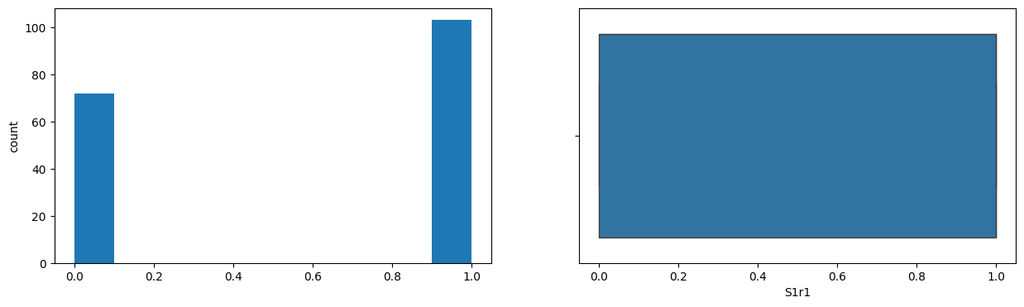

```
S1r2
Skew : 1.71
```

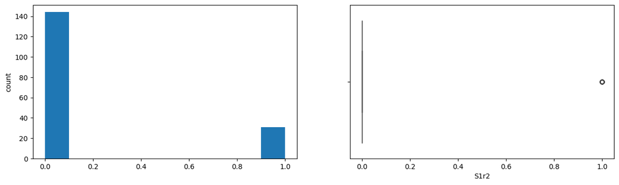

```
S1r3
Skew : 1.87
```

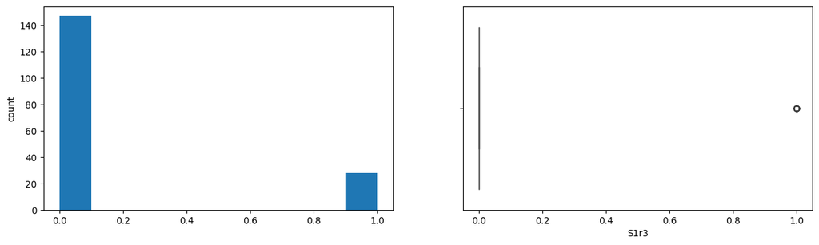

```
S2r1
Skew : -2.13
```

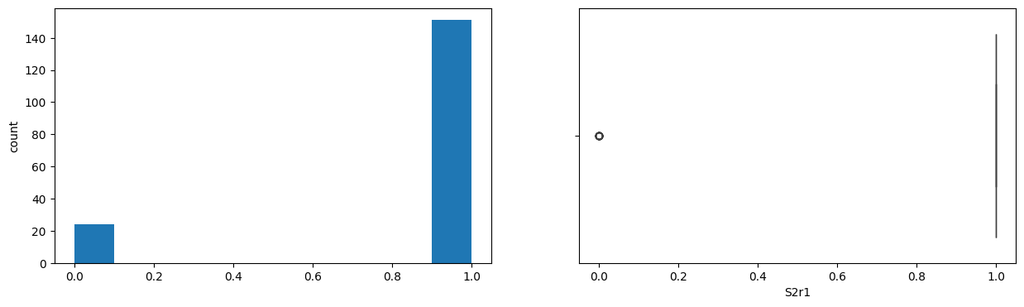

```
S2r2
Skew : 1.99
```

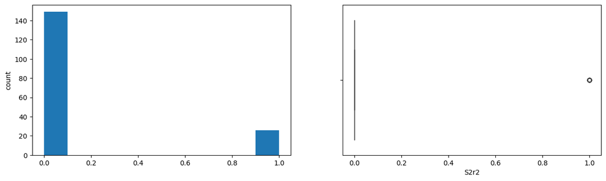

```
S3r1
Skew : 0.32
```

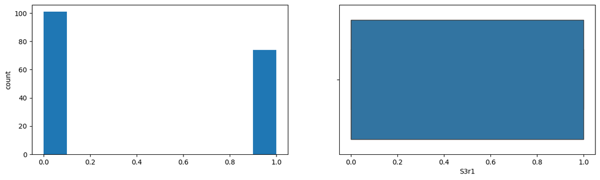

```
S3r2
Skew : 0.2
```

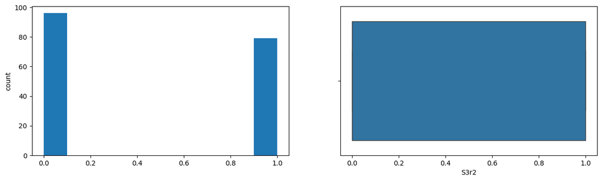

```
S4r1
Skew : 1.43
```

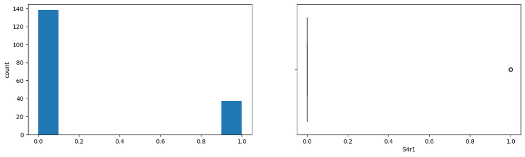

```
S4r2
Skew : 2.06
```

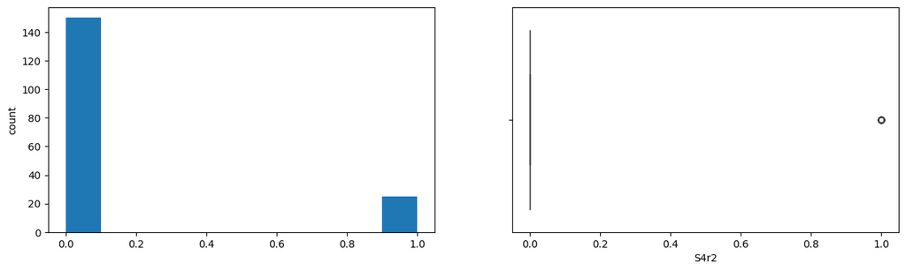

```
S4r3
Skew : 1.34
```

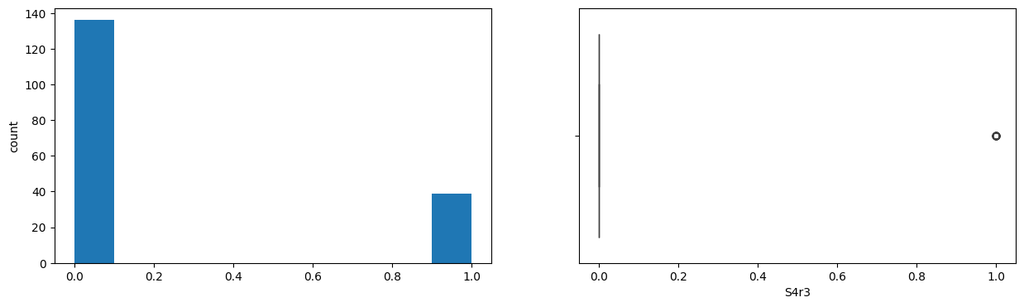

```
S4r4
Skew : 1.34
```

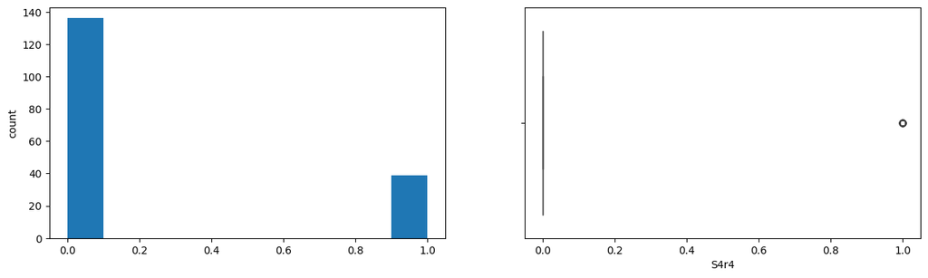

```
S4r5
Skew : 2.86
```

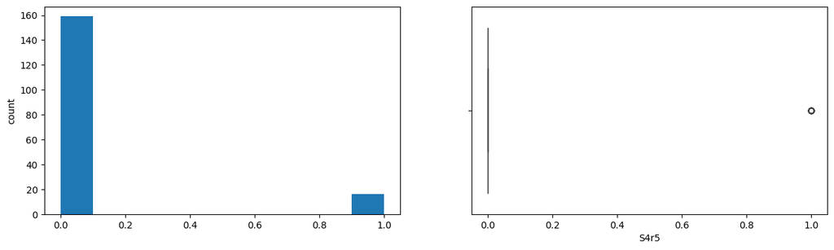

```
S4r6
Skew : 4.39
```

[33 more figures not shown]

```python
for col in data.columns[2:]:
    print(col)
    print('Skew :',round(data[col].skew(),2))
    plt.figure(figsize=(15,4))
    plt.subplot(1,2,1)
    data[col].hist(bins=10, grid=False)
    plt.ylabel('count')
    plt.subplot(1,2,2)
    sns.boxplot(x=data[col])
    plt.show()
```

#### Let's check the correlation among the variables

[figure not shown]

```python
# plt.figure(figsize  = (20,20))
sns.heatmap(data.corr(), annot = True, cmap="YlGnBu")
plt.show()
```

## Data Preprocessing

- We do not really requrie scaling or normalization here as all the coulmns in the data has only binary values
- Remove columns - 'record', 'id' - [0, 1] columns
- Remove 'country' related columns - [2,3,4] columns - because the clustering we are trying to do here is to understand the preferences of shoe or apparel for an idividual and I assume that does not depend on which country they belong to
- Remove 'verification' related columns - [5, 6] and consider only verified participants

```python
data_cleaned = data[(data['S2r1'] == 1) & (data['S2r2'] == 0)]
```

```python
data_cleaned.shape
```

```
(149, 47)
```

```python
data_processed = data_cleaned.iloc[:, 7:]
```

```python
data_processed.shape
```

```
(149, 40)
```

```python
data_processed.head(3)
```

|  | S3r1 | S3r2 | S4r1 | S4r2 | S4r3 | S4r4 | S4r5 | S4r6 | Q1r1 | Q1r2 | ... | Q6r1 | Q6r2 | Q6r3 | Q6r4 | Q6r5 | Q7r1 | Q7r2 | Q7r3 | Q7r4 | Q7r5 |
| --- | --- | --- | --- | --- | --- | --- | --- | --- | --- | --- | --- | --- | --- | --- | --- | --- | --- | --- | --- | --- | --- |
| 0 | 1 | 0 | 0 | 0 | 0 | 0 | 1 | 0 | 0 | 1 | ... | 0 | 1 | 0 | 1 | 0 | 0 | 0 | 1 | 1 | 0 |
| 1 | 1 | 0 | 0 | 0 | 0 | 1 | 0 | 0 | 0 | 1 | ... | 0 | 1 | 0 | 0 | 0 | 0 | 0 | 1 | 0 | 0 |
| 2 | 0 | 1 | 0 | 1 | 0 | 0 | 0 | 0 | 0 | 0 | ... | 0 | 0 | 0 | 0 | 1 | 0 | 1 | 1 | 0 | 0 |

3 rows × 40 columns

```python
#Creating copy of the data to store labels
data_processed_copy = data_processed.copy(deep=True)
```

```python
data_processed_copy.head(3)
```

|  | S3r1 | S3r2 | S4r1 | S4r2 | S4r3 | S4r4 | S4r5 | S4r6 | Q1r1 | Q1r2 | ... | Q6r1 | Q6r2 | Q6r3 | Q6r4 | Q6r5 | Q7r1 | Q7r2 | Q7r3 | Q7r4 | Q7r5 |
| --- | --- | --- | --- | --- | --- | --- | --- | --- | --- | --- | --- | --- | --- | --- | --- | --- | --- | --- | --- | --- | --- |
| 0 | 1 | 0 | 0 | 0 | 0 | 0 | 1 | 0 | 0 | 1 | ... | 0 | 1 | 0 | 1 | 0 | 0 | 0 | 1 | 1 | 0 |
| 1 | 1 | 0 | 0 | 0 | 0 | 1 | 0 | 0 | 0 | 1 | ... | 0 | 1 | 0 | 0 | 0 | 0 | 0 | 1 | 0 | 0 |
| 2 | 0 | 1 | 0 | 1 | 0 | 0 | 0 | 0 | 0 | 0 | ... | 0 | 0 | 0 | 0 | 1 | 0 | 1 | 1 | 0 | 0 |

3 rows × 40 columns

## Similarty Metrics

I am considering Jaccard distance to calculate and measure the similarity in the data. The reason to choose Jaccard distance is:

- Binary Data: The dataset consists primarily of binary (0/1) attributes, making Jaccard similarity especially relevant.
- Set-Based Comparison: Jaccard similarity compares the intersection versus the union of the attributes, ideal for binary sets.

```python
from scipy.spatial.distance import pdist, squareform

# Calculating the pairwise Jaccard distances
jaccard_distances = pdist(data_processed, metric='jaccard')

# Converting the distances to a square matrix form
jaccard_similarity = squareform(1 - jaccard_distances)  # Converting distances to similarity

# If you want to put this into a DataFrame for better readability:
jaccard_similarity_df = pd.DataFrame(jaccard_similarity, index=data_processed.index, columns=data_processed.index)
```

```python
jaccard_similarity_df
```

|  | 0 | 1 | 2 | 3 | 4 | 5 | 6 | 7 | 8 | 9 | ... | 164 | 165 | 166 | 168 | 169 | 170 | 171 | 172 | 173 | 174 |
| --- | --- | --- | --- | --- | --- | --- | --- | --- | --- | --- | --- | --- | --- | --- | --- | --- | --- | --- | --- | --- | --- |
| 0 | 0.000000 | 0.333333 | 0.047619 | 0.111111 | 0.000000 | 0.050000 | 0.111111 | 0.176471 | 0.105263 | 0.294118 | ... | 0.166667 | 0.538462 | 0.000000 | 0.157895 | 0.176471 | 0.052632 | 0.052632 | 0.047619 | 0.052632 | 0.000000 |
| 1 | 0.333333 | 0.000000 | 0.250000 | 0.285714 | 0.000000 | 0.187500 | 0.200000 | 0.200000 | 0.117647 | 0.176471 | ... | 0.117647 | 0.500000 | 0.117647 | 0.176471 | 0.285714 | 0.285714 | 0.285714 | 0.111111 | 0.285714 | 0.176471 |
| 2 | 0.047619 | 0.250000 | 0.000000 | 0.250000 | 0.111111 | 0.312500 | 0.176471 | 0.176471 | 0.105263 | 0.157895 | ... | 0.105263 | 0.052632 | 0.400000 | 0.222222 | 0.250000 | 0.666667 | 0.666667 | 0.375000 | 0.666667 | 0.692308 |
| 3 | 0.111111 | 0.285714 | 0.250000 | 0.000000 | 0.285714 | 0.055556 | 0.800000 | 0.000000 | 0.357143 | 0.176471 | ... | 0.000000 | 0.285714 | 0.117647 | 0.052632 | 0.058824 | 0.200000 | 0.200000 | 0.111111 | 0.200000 | 0.250000 |
| 4 | 0.000000 | 0.000000 | 0.111111 | 0.285714 | 0.000000 | 0.000000 | 0.384615 | 0.000000 | 0.461538 | 0.333333 | ... | 0.000000 | 0.058824 | 0.055556 | 0.000000 | 0.000000 | 0.125000 | 0.125000 | 0.052632 | 0.125000 | 0.111111 |
| ... | ... | ... | ... | ... | ... | ... | ... | ... | ... | ... | ... | ... | ... | ... | ... | ... | ... | ... | ... | ... | ... |
| 170 | 0.052632 | 0.285714 | 0.666667 | 0.200000 | 0.125000 | 0.266667 | 0.125000 | 0.285714 | 0.117647 | 0.111111 | ... | 0.187500 | 0.058824 | 0.461538 | 0.176471 | 0.285714 | 0.000000 | 1.000000 | 0.428571 | 0.636364 | 0.666667 |
| 171 | 0.052632 | 0.285714 | 0.666667 | 0.200000 | 0.125000 | 0.266667 | 0.125000 | 0.285714 | 0.117647 | 0.111111 | ... | 0.187500 | 0.058824 | 0.461538 | 0.176471 | 0.285714 | 1.000000 | 0.000000 | 0.428571 | 0.636364 | 0.666667 |
| 172 | 0.047619 | 0.111111 | 0.375000 | 0.111111 | 0.052632 | 0.500000 | 0.052632 | 0.428571 | 0.050000 | 0.000000 | ... | 0.400000 | 0.000000 | 0.909091 | 0.375000 | 0.333333 | 0.428571 | 0.428571 | 0.000000 | 0.250000 | 0.466667 |
| 173 | 0.052632 | 0.285714 | 0.666667 | 0.200000 | 0.125000 | 0.187500 | 0.125000 | 0.125000 | 0.117647 | 0.176471 | ... | 0.187500 | 0.058824 | 0.266667 | 0.250000 | 0.384615 | 0.636364 | 0.636364 | 0.250000 | 0.000000 | 0.428571 |
| 174 | 0.000000 | 0.176471 | 0.692308 | 0.250000 | 0.111111 | 0.400000 | 0.176471 | 0.250000 | 0.166667 | 0.047619 | ... | 0.235294 | 0.000000 | 0.500000 | 0.294118 | 0.250000 | 0.666667 | 0.666667 | 0.466667 | 0.428571 | 0.000000 |

149 rows × 149 columns

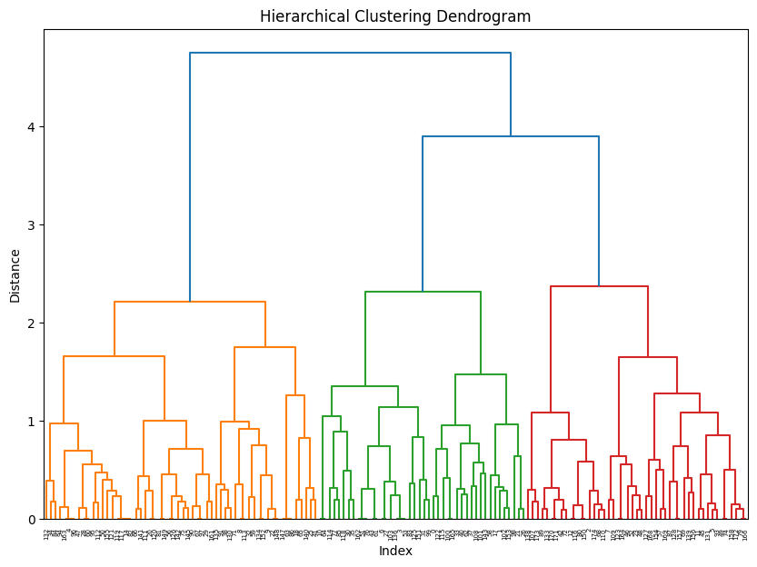

```python
from scipy.cluster.hierarchy import dendrogram, linkage

# Generate the linkage matrix
Z = linkage(jaccard_distances, 'ward')

# Plot the dendrogram
plt.figure(figsize=(10, 7))
dendrogram(Z, labels=data_processed.index)
plt.title('Hierarchical Clustering Dendrogram')
plt.xlabel('Index')
plt.ylabel('Distance')
plt.show()
```

**Observations**:

- From the Dendogram which is plotted based on Jacarrd distances, we can clearly see that there are 3 groups or clusters in a broad sense.
- If we further look down, we can see that there are 2 major groups within the first cluster (colored in orange)
- But, overall 3 clusters is a good split as interpreted from the dendogram

## Model building

### K-Means Clustering

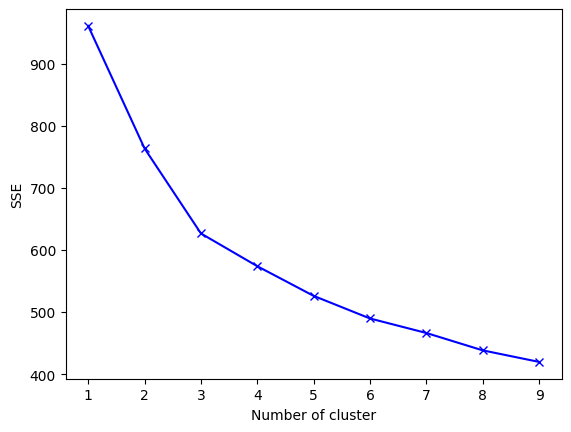

```python
#Empty dictionary to store the SSE for each value of k
sse = {}

# iterate for a range of Ks and fit the scaled data to the algorithm. Use inertia attribute from the clustering object and
# store the inertia value for that k
for k in range(1, 10):
    kmeans = KMeans(n_clusters=k, random_state=1).fit(data_processed)
    sse[k] = kmeans.inertia_

#Elbow plot
plt.figure()
plt.plot(list(sse.keys()), list(sse.values()), 'bx-')
plt.xlabel("Number of cluster")
plt.ylabel("SSE")
plt.show()
```

**Observations:**

- We can see a slight elbow bend at k = 3

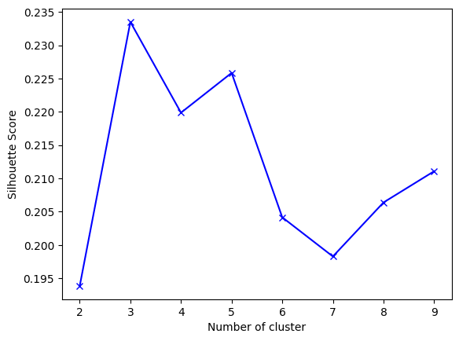

```python
#Empty dictionary to store the Silhouette score for each value of k
sc = {}

# iterate for a range of Ks and fit the scaled data to the algorithm. Store the Silhouette score for that k
for k in range(2, 10):
    kmeans = KMeans(n_clusters=k, random_state=1).fit(data_processed)
    labels = kmeans.predict(data_processed)
    sc[k] = silhouette_score(data_processed, labels)

#Elbow plot
plt.figure()
plt.plot(list(sc.keys()), list(sc.values()), 'bx-')
plt.xlabel("Number of cluster")
plt.ylabel("Silhouette Score")
plt.show()
```

**Observations:**

- We can see the highest silhouette score for k = 3

```python
# Getting the k value with highest silhouette_score
silh_dict = {}
for s in range(2,10):
  k_test = KMeans(n_clusters=s, n_init='auto', random_state=50).fit(data_processed)
  score = silhouette_score(data_processed, k_test.labels_)
# Print the score
  print(f'Silhouette Score of {s} is : {score.round(4)}') #rounding the value to 4 decimal places
  silh_dict[s] = score #
  #print(silh_dict)
silh_max = max(silh_dict, key = silh_dict.get)
silh_max_value =  max(silh_dict.values()) #best k value based on the score
print(f'k value {silh_max} has the highest silhoutte score value : {silh_max_value} compared to other k values')
```

```
Silhouette Score of 2 is : 0.2016
Silhouette Score of 3 is : 0.2333
Silhouette Score of 4 is : 0.2131
Silhouette Score of 5 is : 0.2125
Silhouette Score of 6 is : 0.2212
Silhouette Score of 7 is : 0.2022
Silhouette Score of 8 is : 0.2087
Silhouette Score of 9 is : 0.1899
k value 3 has the highest silhoutte score value : 0.23331306930824433 compared to other k values
```

#### k = 3

```python
kmeans = KMeans(n_clusters = 3, random_state = 1)
kmeans.fit(data_processed)

#Adding predicted labels to the original data and scaled data
data_processed_copy['KMeans_Labels'] = kmeans.predict(data_processed)
# data_cleaned['KMeans_Labels'] = kmeans.predict(data_cleaned)
```

```python
data_processed_copy['KMeans_Labels'].value_counts()
```

```
KMeans_Labels
0    53
1    50
2    46
Name: count, dtype: int64
```

**Observations** :

- This looks like a good distribution of clustering, with good number of records in each cluster. Also, the clusters have almost same number of records.

#### Analysing clusters

##### 1. Gender

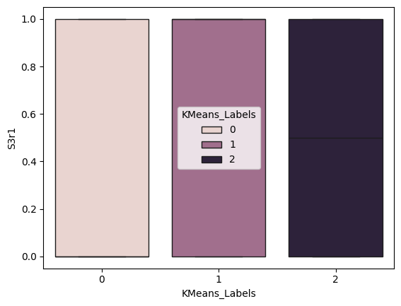

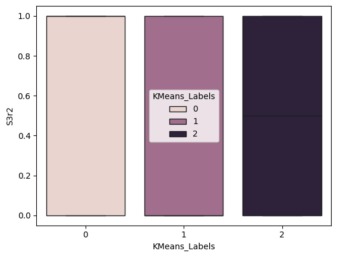

```python
cols_visualise = [col for col in data_processed_copy.columns if 'S3' in col]

for col in cols_visualise:
    sns.boxplot(x = 'KMeans_Labels', y = col, data = data_processed_copy, hue = 'KMeans_Labels')
    plt.show()
```

##### 2. Age

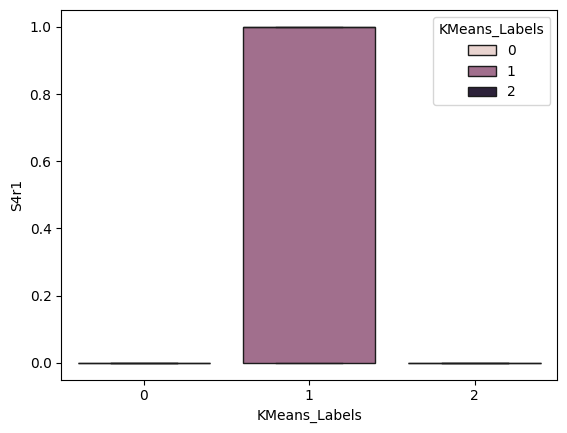

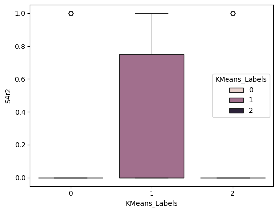

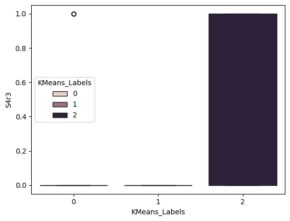

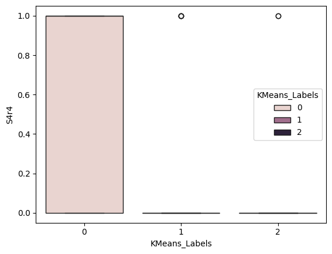

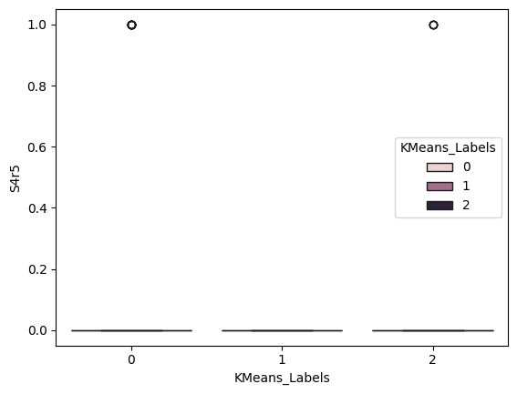

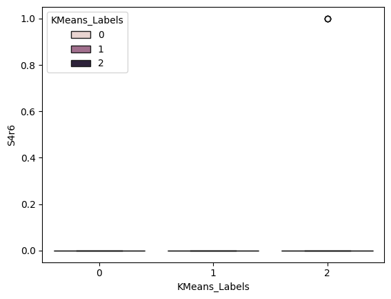

```python
cols_visualise = [col for col in data_processed_copy.columns if 'S4' in col]

for col in cols_visualise:
    sns.boxplot(x = 'KMeans_Labels', y = col, data = data_processed_copy, hue = 'KMeans_Labels')
    plt.show()
```

##### 3. Q1: How regularly do you go for a run?

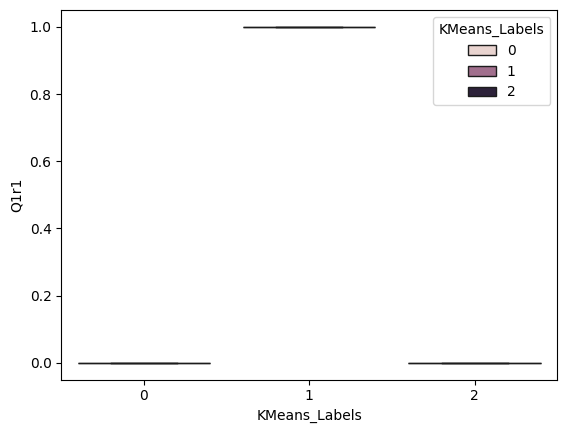

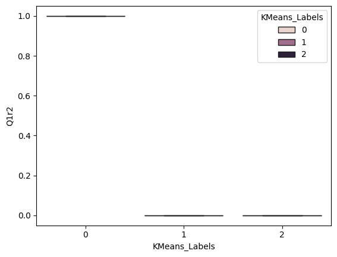

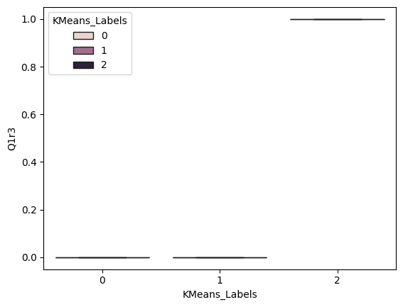

```python
cols_visualise = [col for col in data_processed_copy.columns if 'Q1' in col]

for col in cols_visualise:
    sns.boxplot(x = 'KMeans_Labels', y = col, data = data_processed_copy, hue = 'KMeans_Labels')
    plt.show()
```

##### 3. Q2: How many pairs of running shoes do you own at the time when you train?

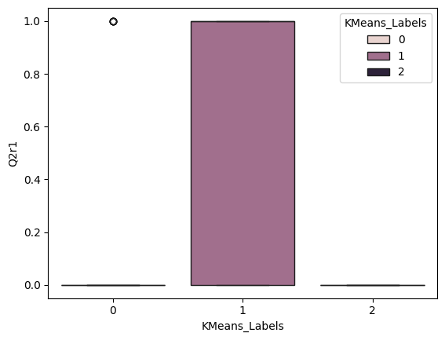

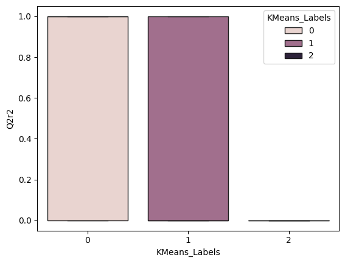

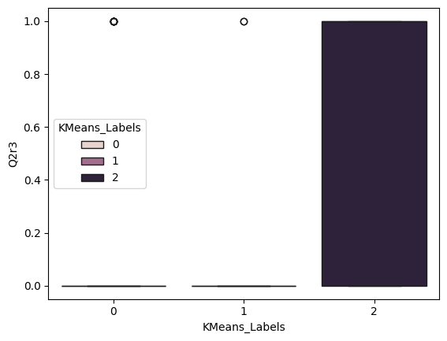

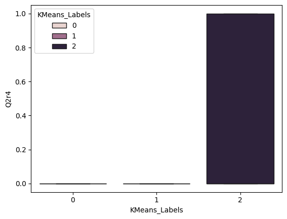

```python
cols_visualise = [col for col in data_processed_copy.columns if 'Q2' in col]

for col in cols_visualise:
    sns.boxplot(x = 'KMeans_Labels', y = col, data = data_processed_copy, hue = 'KMeans_Labels')
    plt.show()
```